# Customer Service Requests Analysis

- DESCRIPTION
- Background of Problem Statement :

NYC 311's mission is to provide the public with quick and easy access to all New York City government services and information while offering the best customer service. Each day, NYC311 receives thousands of requests related to several hundred types of non-emergency services, including noise complaints, plumbing issues, and illegally parked cars. These requests are received by NYC311 and forwarded to the relevant agencies such as the police, buildings, or transportation. The agency responds to the request, addresses it, and then closes it.

- Problem Objective :

Perform a service request data analysis of New York City 311 calls. You will focus on the data wrangling techniques to understand the pattern in the data and also visualize the major complaint types. Domain: Customer Service

- Analysis Tasks to be performed:

(Perform a service request data analysis of New York City 311 calls)

- Import a 311 NYC service request.
- Read or convert the columns ‘Created Date’ and Closed Date’ to datetime datatype and create a new column ‘Request_Closing_Time’ as the time elapsed between request creation and request closing. (Hint: Explore the package/module datetime)
- Provide major insights/patterns that you can offer in a visual format (graphs or tables); at least 4 major conclusions that you can come up with after generic data mining.
- Order the complaint types based on the average ‘Request_Closing_Time’, grouping them for different locations.
- Perform a statistical test for the following:
- Please note: For the below statements you need to state the Null and Alternate and then provide a statistical test to accept or reject the Null Hypothesis along with the corresponding ‘p-value’.
- Whether the average response time across complaint types is similar or not (overall)
- Are the type of complaint or service requested and location related?

```python
import pandas as pd
import numpy as np
```

```python
nyc311df = pd.read_csv('311_Service_Requests_from_2010_to_Present.csv', low_memory=False)
nyc311df.head(10)
```

|  | Unique Key | Created Date | Closed Date | Agency | Agency Name | Complaint Type | Descriptor | Location Type | Incident Zip | Incident Address | ... | Bridge Highway Name | Bridge Highway Direction | Road Ramp | Bridge Highway Segment | Garage Lot Name | Ferry Direction | Ferry Terminal Name | Latitude | Longitude | Location |
| --- | --- | --- | --- | --- | --- | --- | --- | --- | --- | --- | --- | --- | --- | --- | --- | --- | --- | --- | --- | --- | --- |
| 0 | 32310363 | 12/31/2015 11:59:45 PM | 01-01-16 0:55 | NYPD | New York City Police Department | Noise - Street/Sidewalk | Loud Music/Party | Street/Sidewalk | 10034.0 | 71 VERMILYEA AVENUE | ... | NaN | NaN | NaN | NaN | NaN | NaN | NaN | 40.865682 | -73.923501 | (40.86568153633767, -73.92350095571744) |
| 1 | 32309934 | 12/31/2015 11:59:44 PM | 01-01-16 1:26 | NYPD | New York City Police Department | Blocked Driveway | No Access | Street/Sidewalk | 11105.0 | 27-07 23 AVENUE | ... | NaN | NaN | NaN | NaN | NaN | NaN | NaN | 40.775945 | -73.915094 | (40.775945312321085, -73.91509393898605) |
| 2 | 32309159 | 12/31/2015 11:59:29 PM | 01-01-16 4:51 | NYPD | New York City Police Department | Blocked Driveway | No Access | Street/Sidewalk | 10458.0 | 2897 VALENTINE AVENUE | ... | NaN | NaN | NaN | NaN | NaN | NaN | NaN | 40.870325 | -73.888525 | (40.870324522111424, -73.88852464418646) |
| 3 | 32305098 | 12/31/2015 11:57:46 PM | 01-01-16 7:43 | NYPD | New York City Police Department | Illegal Parking | Commercial Overnight Parking | Street/Sidewalk | 10461.0 | 2940 BAISLEY AVENUE | ... | NaN | NaN | NaN | NaN | NaN | NaN | NaN | 40.835994 | -73.828379 | (40.83599404683083, -73.82837939584206) |
| 4 | 32306529 | 12/31/2015 11:56:58 PM | 01-01-16 3:24 | NYPD | New York City Police Department | Illegal Parking | Blocked Sidewalk | Street/Sidewalk | 11373.0 | 87-14 57 ROAD | ... | NaN | NaN | NaN | NaN | NaN | NaN | NaN | 40.733060 | -73.874170 | (40.733059618956815, -73.87416975810375) |
| 5 | 32306554 | 12/31/2015 11:56:30 PM | 01-01-16 1:50 | NYPD | New York City Police Department | Illegal Parking | Posted Parking Sign Violation | Street/Sidewalk | 11215.0 | 260 21 STREET | ... | NaN | NaN | NaN | NaN | NaN | NaN | NaN | 40.660823 | -73.992568 | (40.66082272389114, -73.99256786342693) |
| 6 | 32306559 | 12/31/2015 11:55:32 PM | 01-01-16 1:53 | NYPD | New York City Police Department | Illegal Parking | Blocked Hydrant | Street/Sidewalk | 10032.0 | 524 WEST 169 STREET | ... | NaN | NaN | NaN | NaN | NaN | NaN | NaN | 40.840848 | -73.937375 | (40.840847591440415, -73.9373750864581) |
| 7 | 32307009 | 12/31/2015 11:54:05 PM | 01-01-16 1:42 | NYPD | New York City Police Department | Blocked Driveway | No Access | Street/Sidewalk | 10457.0 | 501 EAST 171 STREET | ... | NaN | NaN | NaN | NaN | NaN | NaN | NaN | 40.837503 | -73.902905 | (40.83750262540012, -73.90290517326568) |
| 8 | 32308581 | 12/31/2015 11:53:58 PM | 01-01-16 8:27 | NYPD | New York City Police Department | Illegal Parking | Posted Parking Sign Violation | Street/Sidewalk | 11415.0 | 83-44 LEFFERTS BOULEVARD | ... | NaN | NaN | NaN | NaN | NaN | NaN | NaN | 40.704977 | -73.832605 | (40.704977164399935, -73.8326047502584) |
| 9 | 32308391 | 12/31/2015 11:53:58 PM | 01-01-16 1:17 | NYPD | New York City Police Department | Blocked Driveway | No Access | Street/Sidewalk | 11219.0 | 1408 66 STREET | ... | NaN | NaN | NaN | NaN | NaN | NaN | NaN | 40.623793 | -73.999539 | (40.623793065806524, -73.99953890121567) |

10 rows × 53 columns

```python
nyc311df.shape
```

```
(300698, 53)
```

```python
nyc311df.info()
```

```
<class 'pandas.core.frame.DataFrame'>
RangeIndex: 300698 entries, 0 to 300697
Data columns (total 53 columns):
 #   Column                          Non-Null Count   Dtype
---  ------                          --------------   -----
 0   Unique Key                      300698 non-null  int64
 1   Created Date                    300698 non-null  object
 2   Closed Date                     298534 non-null  object
 3   Agency                          300698 non-null  object
 4   Agency Name                     300698 non-null  object
 5   Complaint Type                  300698 non-null  object
 6   Descriptor                      294784 non-null  object
 7   Location Type                   300567 non-null  object
 8   Incident Zip                    298083 non-null  float64
 9   Incident Address                256288 non-null  object
```

[output cut: 45 more lines]

```python
nyc311df.duplicated().sum()
```

```
0
```

```python
nyc311df.isnull().sum()
```

```
Unique Key                             0
Created Date                           0
Closed Date                         2164
Agency                                 0
Agency Name                            0
Complaint Type                         0
Descriptor                          5914
Location Type                        131
Incident Zip                        2615
Incident Address                   44410
Street Name                        44410
Cross Street 1                     49279
Cross Street 2                     49779
Intersection Street 1             256840
Intersection Street 2             257336
Address Type                        2815
City                                2614
Landmark                          300349
Facility Type                       2171
Status                                 0
Due Date                               3
Resolution Description                 0
Resolution Action Updated Date      2187
Community Board                        0
Borough                                0
X Coordinate (State Plane)          3540
Y Coordinate (State Plane)          3540
Park Facility Name                     0
Park Borough                           0
School Name                            0
School Number                          0
School Region                          1
School Code                            1
School Phone Number                    0
School Address                         0
School City                            0
School State                           0
School Zip                             1
School Not Found                       0
School or Citywide Complaint      300698
Vehicle Type                      300698
Taxi Company Borough              300698
Taxi Pick Up Location             300698
Bridge Highway Name               300455
Bridge Highway Direction          300455
Road Ramp                         300485
Bridge Highway Segment            300485
Garage Lot Name                   300698
Ferry Direction                   300697
Ferry Terminal Name               300696
Latitude                            3540
Longitude                           3540
Location                            3540
dtype: int64
```

```python
nyc311df.isna().sum()
```

```
Unique Key                             0
Created Date                           0
Closed Date                         2164
Agency                                 0
Agency Name                            0
Complaint Type                         0
Descriptor                          5914
Location Type                        131
Incident Zip                        2615
Incident Address                   44410
Street Name                        44410
Cross Street 1                     49279
Cross Street 2                     49779
Intersection Street 1             256840
Intersection Street 2             257336
Address Type                        2815
City                                2614
Landmark                          300349
Facility Type                       2171
Status                                 0
Due Date                               3
Resolution Description                 0
Resolution Action Updated Date      2187
Community Board                        0
Borough                                0
X Coordinate (State Plane)          3540
Y Coordinate (State Plane)          3540
Park Facility Name                     0
Park Borough                           0
School Name                            0
School Number                          0
School Region                          1
School Code                            1
School Phone Number                    0
School Address                         0
School City                            0
School State                           0
School Zip                             1
School Not Found                       0
School or Citywide Complaint      300698
Vehicle Type                      300698
Taxi Company Borough              300698
Taxi Pick Up Location             300698
Bridge Highway Name               300455
Bridge Highway Direction          300455
Road Ramp                         300485
Bridge Highway Segment            300485
Garage Lot Name                   300698
Ferry Direction                   300697
Ferry Terminal Name               300696
Latitude                            3540
Longitude                           3540
Location                            3540
dtype: int64
```

```python
# drop unnessery cols with too much null (more than 300000)
nyc311df.drop(['School or Citywide Complaint', 'Vehicle Type', 'Taxi Company Borough', 'Taxi Pick Up Location',
               'Bridge Highway Name','Bridge Highway Direction', 'Road Ramp','Bridge Highway Segment',
               'Bridge Highway Segment', 'Garage Lot Name', 'Ferry Direction',
               'Ferry Terminal Name', 'Landmark'], axis = 1, inplace = True)
```

```python
#drop NA from nessery col
nyc311df.dropna(subset=['City','Latitude'],inplace=True)
```

```python
nyc311df.to_csv('Nyc_cleaned.csv',index=False)
```

```python
nyc311df.shape
```

```
(297117, 41)
```

```python
nyc311df = pd.read_csv('Nyc_cleaned.csv',parse_dates=['Created Date','Closed Date', 'Resolution Action Updated Date'])
nyc311df.head()
```

|  | Unique Key | Created Date | Closed Date | Agency | Agency Name | Complaint Type | Descriptor | Location Type | Incident Zip | Incident Address | ... | School Code | School Phone Number | School Address | School City | School State | School Zip | School Not Found | Latitude | Longitude | Location |
| --- | --- | --- | --- | --- | --- | --- | --- | --- | --- | --- | --- | --- | --- | --- | --- | --- | --- | --- | --- | --- | --- |
| 0 | 32310363 | 2015-12-31 23:59:45 | 2016-01-01 00:55:00 | NYPD | New York City Police Department | Noise - Street/Sidewalk | Loud Music/Party | Street/Sidewalk | 10034.0 | 71 VERMILYEA AVENUE | ... | Unspecified | Unspecified | Unspecified | Unspecified | Unspecified | Unspecified | N | 40.865682 | -73.923501 | (40.86568153633767, -73.92350095571744) |
| 1 | 32309934 | 2015-12-31 23:59:44 | 2016-01-01 01:26:00 | NYPD | New York City Police Department | Blocked Driveway | No Access | Street/Sidewalk | 11105.0 | 27-07 23 AVENUE | ... | Unspecified | Unspecified | Unspecified | Unspecified | Unspecified | Unspecified | N | 40.775945 | -73.915094 | (40.775945312321085, -73.91509393898605) |
| 2 | 32309159 | 2015-12-31 23:59:29 | 2016-01-01 04:51:00 | NYPD | New York City Police Department | Blocked Driveway | No Access | Street/Sidewalk | 10458.0 | 2897 VALENTINE AVENUE | ... | Unspecified | Unspecified | Unspecified | Unspecified | Unspecified | Unspecified | N | 40.870325 | -73.888525 | (40.870324522111424, -73.88852464418646) |
| 3 | 32305098 | 2015-12-31 23:57:46 | 2016-01-01 07:43:00 | NYPD | New York City Police Department | Illegal Parking | Commercial Overnight Parking | Street/Sidewalk | 10461.0 | 2940 BAISLEY AVENUE | ... | Unspecified | Unspecified | Unspecified | Unspecified | Unspecified | Unspecified | N | 40.835994 | -73.828379 | (40.83599404683083, -73.82837939584206) |
| 4 | 32306529 | 2015-12-31 23:56:58 | 2016-01-01 03:24:00 | NYPD | New York City Police Department | Illegal Parking | Blocked Sidewalk | Street/Sidewalk | 11373.0 | 87-14 57 ROAD | ... | Unspecified | Unspecified | Unspecified | Unspecified | Unspecified | Unspecified | N | 40.733060 | -73.874170 | (40.733059618956815, -73.87416975810375) |

5 rows × 41 columns

```python
nyc311df['Request_Closing_Time'] = nyc311df['Closed Date'].values - nyc311df['Created Date'].values
nyc311df['Request_Closing_Time_min'] = nyc311df['Request_Closing_Time']/np.timedelta64(1,'m')
```

```python
nyc311df.dtypes
```

```
Unique Key                                  int64
Created Date                       datetime64[ns]
Closed Date                        datetime64[ns]
Agency                                     object
Agency Name                                object
Complaint Type                             object
Descriptor                                 object
Location Type                              object
Incident Zip                              float64
Incident Address                           object
Street Name                                object
Cross Street 1                             object
Cross Street 2                             object
Intersection Street 1                      object
Intersection Street 2                      object
Address Type                               object
City                                       object
Facility Type                              object
Status                                     object
Due Date                                   object
Resolution Description                     object
Resolution Action Updated Date     datetime64[ns]
Community Board                            object
Borough                                    object
X Coordinate (State Plane)                float64
Y Coordinate (State Plane)                float64
Park Facility Name                         object
Park Borough                               object
School Name                                object
School Number                              object
School Region                              object
School Code                                object
School Phone Number                        object
School Address                             object
School City                                object
School State                               object
School Zip                                 object
School Not Found                           object
Latitude                                  float64
Longitude                                 float64
Location                                   object
Request_Closing_Time              timedelta64[ns]
Request_Closing_Time_min                  float64
dtype: object
```

```python
import matplotlib.pyplot as plt
import seaborn as sns
%matplotlib inline
```

**Complaints Status**

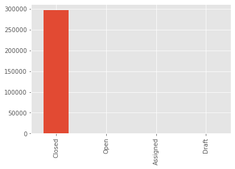

```python
from matplotlib import style
style.use('ggplot')
nyc311df['Status'].value_counts().plot(kind='bar')
plt.show()
```

**Cities with most complaints**

```python
nyc311df['City'].value_counts()
```

```
BROOKLYN               98113
NEW YORK               65402
BRONX                  40595
STATEN ISLAND          12335
JAMAICA                 7286
ASTORIA                 6315
FLUSHING                5967
RIDGEWOOD               5161
CORONA                  4294
WOODSIDE                3541
SOUTH RICHMOND HILL     2773
OZONE PARK              2755
EAST ELMHURST           2734
ELMHURST                2673
WOODHAVEN               2464
MASPETH                 2461
LONG ISLAND CITY        2429
SOUTH OZONE PARK        2173
RICHMOND HILL           1904
FRESH MEADOWS           1895
QUEENS VILLAGE          1814
MIDDLE VILLAGE          1765
JACKSON HEIGHTS         1689
FOREST HILLS            1686
REGO PARK               1484
COLLEGE POINT           1220
BAYSIDE                 1219
FAR ROCKAWAY            1178
WHITESTONE              1098
HOLLIS                  1012
HOWARD BEACH             930
ROSEDALE                 918
SPRINGFIELD GARDENS      883
SAINT ALBANS             834
KEW GARDENS              771
ROCKAWAY PARK            743
SUNNYSIDE                723
Astoria                  717
LITTLE NECK              559
OAKLAND GARDENS          549
CAMBRIA HEIGHTS          477
BELLEROSE                375
GLEN OAKS                306
ARVERNE                  220
FLORAL PARK              152
Long Island City         134
Woodside                 120
NEW HYDE PARK             98
CENTRAL PARK              97
QUEENS                    31
BREEZY POINT              30
East Elmhurst             14
Howard Beach               1
Name: City, dtype: int64
```

**Most Complaint Types Recieved**

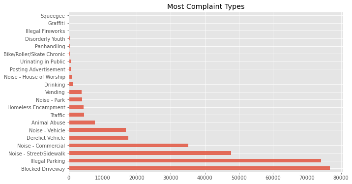

```python
from matplotlib import style
style.use('ggplot')
nyc311df['Complaint Type'].value_counts().plot(kind='barh', alpha=0.8 , figsize=(10,6))
plt.title('Most Complaint Types')
plt.show()
```

**Cities that shows heighr number of 'Blocked Driveway Complaints'**

```python
a = nyc311df[(nyc311df['Complaint Type'] == 'Blocked Driveway')]
```

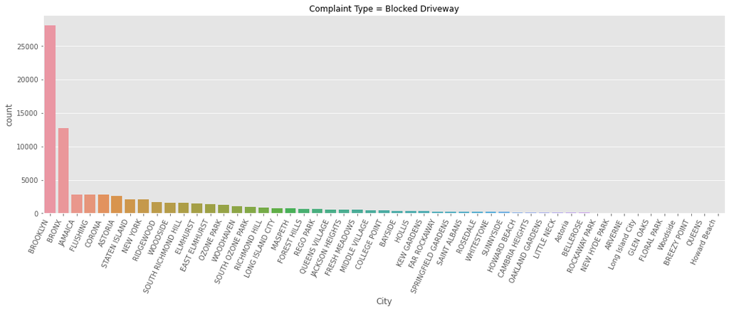

```python
chart= sns.catplot(x='City', col='Complaint Type', kind='count', data=a, height=5, aspect=3,
                   order=a['City'].value_counts().index)
chart.set_xticklabels(rotation=65, horizontalalignment='right')
```

**Distrbution of complaints creation date**

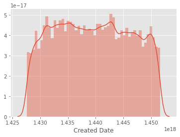

```python
sns.distplot(nyc311df['Created Date'])
```

```python
#Order the complaint types based on the average ‘Request_Closing_Time’, grouping them for different locations.
nyccc=nyc311df.groupby(['City', 'Complaint Type'])
nyccc.mean()['Request_Closing_Time_min']
```

```
City      Complaint Type
ARVERNE   Animal Abuse               129.217544
          Blocked Driveway           151.558095
          Derelict Vehicle           178.093210
          Disorderly Youth           215.475000
          Drinking                    14.316667
                                        ...
Woodside  Blocked Driveway           384.372727
          Derelict Vehicle           298.000000
          Illegal Parking            313.152167
          Noise - Commercial         143.650000
          Noise - Street/Sidewalk    204.676667
Name: Request_Closing_Time_min, Length: 763, dtype: float64
```

```python
nyccc1=nyc311df.groupby(['Location', 'Complaint Type'])
nyccc1.mean()['Request_Closing_Time_min']
```

```
Location                                  Complaint Type
(40.49913462101514, -74.24348482977875)   Illegal Parking             11.833333
(40.49967332981336, -74.2379063249761)    Derelict Vehicle            32.516667
(40.49994886080869, -74.23740031497493)   Illegal Parking            659.016667
(40.49999700116009, -74.23801175120917)   Illegal Parking            910.000000
(40.50002168207532, -74.23802262609722)   Illegal Parking             82.900000
                                                                        ...
(40.91218391108232, -73.90075914042282)   Blocked Driveway           175.716667
(40.91220586223159, -73.90075187169981)   Illegal Parking            145.083333
(40.91234427543014, -73.902133732632)     Noise - Street/Sidewalk    379.000000
(40.912868795316655, -73.90247305278565)  Illegal Parking            777.058333
                                          Noise - Vehicle             28.500000
Name: Request_Closing_Time_min, Length: 151504, dtype: float64
```

```python
# Dropping NA values for statistical testing
nyc311df.dropna(subset=['Request_Closing_Time','Request_Closing_Time_min'],inplace=True)
```

**F-Test**

- Testing at Confidence level(95%) => alpha = 0.05
- Null Hypothesis : H0 : There is no significant difference in average response time across different complaint types
- Alternate Hypothesis : H1 : There is a significant difference in average response time across different complaint types

```python
import scipy.stats as stats
```

```python
# Storing mean response time for various complaint types
complaints = nyc311df['Complaint Type'].value_counts().index
for i in range(len(complaints)):
    exec("sample{} = nyc311df.loc[(nyc311df['Complaint Type'] == '{}') ,\
         'Request_Closing_Time_min']".format(i+1 ,complaints[i]))
```

```python
# Performing F-statics
fscore,pvalue = stats.f_oneway(sample1,sample2,sample3,sample4,sample5,sample6,sample7,sample8,sample9,
                               sample10,sample11,sample12,sample13,sample14,sample15,sample16,sample17,sample18,
                               sample19,sample20,sample21)
print("score : {:.2f} , p-value : {:.2f}".format(fscore,pvalue))
```

```
score : 407.78 , p-value : 0.00
```

**p-value = 0.00 < alpha = 0.05**

- So we reject Null Hypothesis
- There is a significant difference in response time average across different complaint types
- (i.e) the response time average across different complaint types is not similar (overall)

**Chi-Square Test of Independence**

- Testing at Confidence level(95%) => alpha = 0.05
- Null Hypothesis : H0 : There is no significant relation between type of complaint and location
- Alternate Hypothesis : H1 : There is some significant relation between type of complaint and location

```python
# Performing Chi-square test of independence
location_complaint_type = pd.crosstab(nyc311df['Complaint Type'],nyc311df['Location'])
```

```python
cscore,pval,df,et = stats.chi2_contingency(location_complaint_type)
print("score : {:.2f} , p-value : {:.2f}".format(cscore,pval))
```

```
score : 4160248.36 , p-value : 0.00
```

**p-value (0.00) < alpha value(0.05)**

- So we reject our Null Hypothesis
- There is some significant relation between type of complaint and location
- (i.e) The type of complaint or service requested and the location are related